# project1_ReproducibleResearch

This assignment makes use of data from a personal activity monitoring device. This device collects data at 5 minute intervals through out the day. The data consists of two months of data from an anonymous individual collected during the months of October and November, 2012 and include the number of steps taken in 5 minute intervals each day.

## Loading and preprocessing the data

```r
data<-read.csv("activity.csv", header=T, sep=",")
data$date<-as.Date(data$date)
weekday<-weekdays(data$date)
data<-cbind(data, weekday)

summary(data)
```

```
##      steps             date               interval          weekday
##  Min.   :  0.00   Min.   :2012-10-01   Min.   :   0.0   dimanche:2304
##  1st Qu.:  0.00   1st Qu.:2012-10-16   1st Qu.: 588.8   jeudi   :2592
##  Median :  0.00   Median :2012-10-31   Median :1177.5   lundi   :2592
##  Mean   : 37.38   Mean   :2012-10-31   Mean   :1177.5   mardi   :2592
##  3rd Qu.: 12.00   3rd Qu.:2012-11-15   3rd Qu.:1766.2   mercredi:2592
##  Max.   :806.00   Max.   :2012-11-30   Max.   :2355.0   samedi  :2304
##  NA's   :2304                                           vendredi:2592
```

## What is mean total number of steps taken per day?

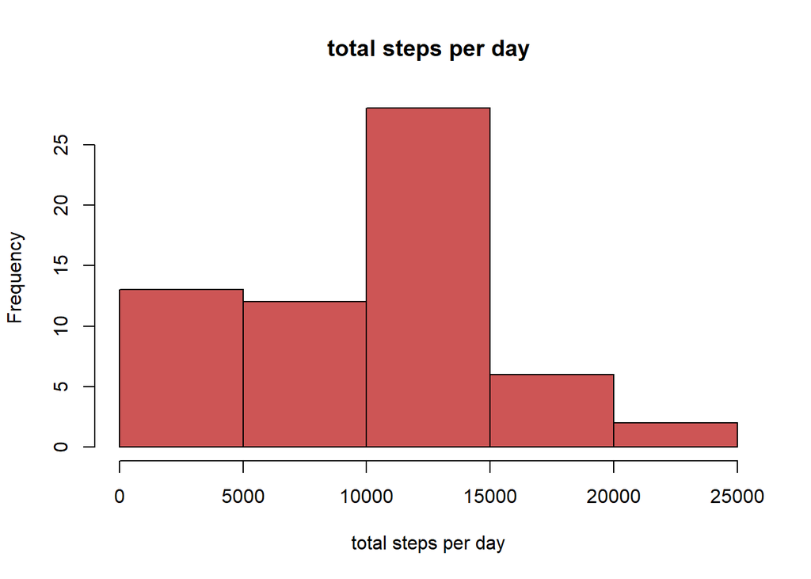

```r
total_steps <- with(data, aggregate(steps, by = list(date), FUN = sum, na.rm = TRUE))
names(total_steps)<-cbind("date","steps")

hist(total_steps$steps, xlab="total steps per day", main="total steps per day", col="indianred3")
```

What are the mean and the median of total number of steps per day?

```r
mean(total_steps$steps)
```

```
## [1] 9354.23
```

```r
median(total_steps$steps)
```

```
## [1] 10395
```

## What is the average daily activity pattern?

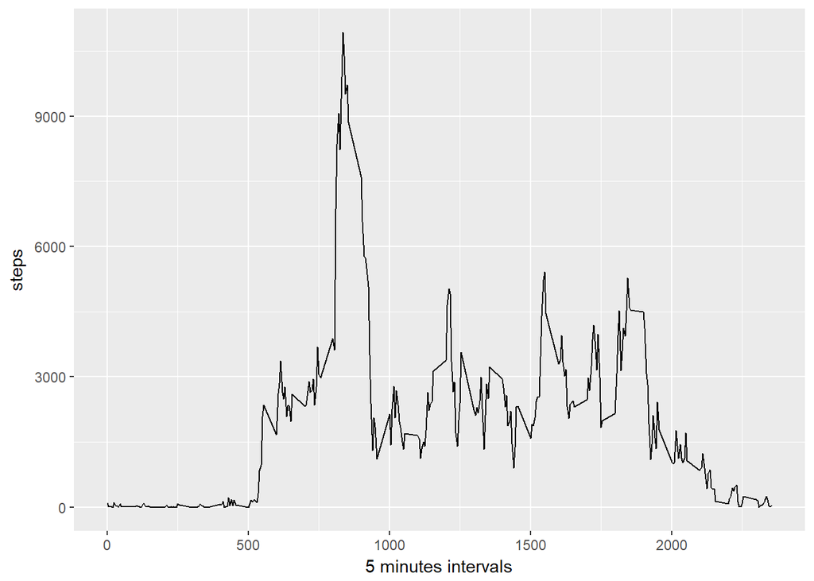

```r
library(ggplot2)

daily_steps <- with(data, aggregate(steps, by = list(interval), FUN = sum, na.rm = TRUE))
names(daily_steps)<-cbind("interval","steps")
ggplot(daily_steps, aes(interval, steps))+geom_line()+xlab("5 minutes intervals")
```

Which 5-minute interval, on average across all the days in the dataset, contains the maximum number of steps?

```r
daily_steps[which(daily_steps$steps==max(daily_steps)),1]
```

```
## [1] 835
```

## Imputing missing values

Total number of rows with NAs

```r
sum(is.na(data$steps))
```

```
## [1] 2304
```

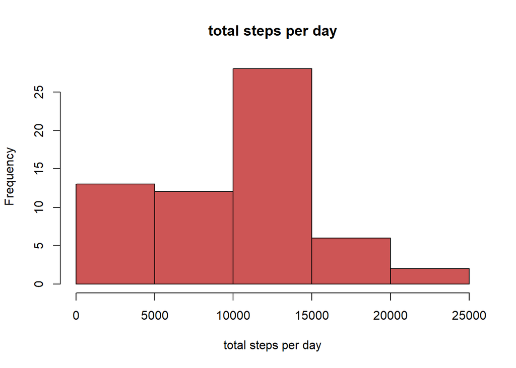

```r
imputed_steps <- total_steps$steps[match(data$date, total_steps$date)]
newdata<- transform(data, steps = ifelse(is.na(data$steps), yes = imputed_steps, no = data$steps))
newtotal_steps <- with(newdata, aggregate(steps, by = list(date), FUN = sum, na.rm = TRUE))
names(newtotal_steps)<-cbind("date","steps")

hist(newtotal_steps$steps, xlab="total steps per day", main="total steps per day", col="indianred3")
```

What are the mean and the median of total number of steps per day with this new dataset?

```r
mean(newtotal_steps$steps)
```

```
## [1] 9354.23
```

```r
median(newtotal_steps$steps)
```

```
## [1] 10395
```

## Are there differences in activity patterns between weekdays and weekends?

Creation of a new factor variable in the dataset with two levels - “weekday” and “weekend”

```r
daylist<-as.character(newdata$weekday)
day<- ifelse(daylist %in% c("samedi","dimanche"), "weekend", "weekday")
finaldata<-cbind(newdata, day)
summary(finaldata)
```

```
##      steps             date               interval          weekday
##  Min.   :  0.00   Min.   :2012-10-01   Min.   :   0.0   dimanche:2304
##  1st Qu.:  0.00   1st Qu.:2012-10-16   1st Qu.: 588.8   jeudi   :2592
##  Median :  0.00   Median :2012-10-31   Median :1177.5   lundi   :2592
##  Mean   : 32.48   Mean   :2012-10-31   Mean   :1177.5   mardi   :2592
##  3rd Qu.:  0.00   3rd Qu.:2012-11-15   3rd Qu.:1766.2   mercredi:2592
##  Max.   :806.00   Max.   :2012-11-30   Max.   :2355.0   samedi  :2304
##                                                         vendredi:2592
##       day
##  weekday:12960
##  weekend: 4608
##
##
##
##
##
```

[figure not shown]

```r
final_daily_steps <- with(finaldata, aggregate(steps~interval+day, FUN = sum, na.rm = TRUE))
ggplot(final_daily_steps, aes(interval, steps))+facet_grid(.~day)+geom_line()+xlab("5 minutes intervals")+ggtitle("average number of steps, weekdays vs weekends")
```